# 과제 #3

### 2. Regression on Simulated Data  
(i) rnorm() 함수를 활용해서 표준정규분포로부터 길이가 100인 feature vector 를 생성하고, 평균이 0, 표준편차가 3인 정규분포로부터 길이가 100인 오차 vector 을 생성한다. (ii) 길이가 100인 target vector 를 다음 식을 사용하여 생성한다. Y = 1 + 2X + 3X2 + 4X3 + ϵ 즉, 실제 regression coefficient β0 = 1 β1 = 2 β2 = 3 β3 = 4 과 같고, 이를 추정하기 위한 linear regression model을 아래의 순서대로 만들어보자.

```r
set.seed(123)
X=rnorm(100)
E=rnorm(100,mean=0,sd=3)
Y=1+2*X+3*X^2+4*X^3+E
Y
```

```
##   [1]  -2.01402761   1.42046042  25.81402968   0.11470540  -1.53748993
##   [6]  33.29848781   0.59612532  -9.83112292  -1.39522234   3.10744978
##  [11]  13.55379181   4.11825320  -2.31276791   1.09685527   1.68648814
##  [16]  37.87933517   3.54987395 -23.67682387   2.70928722  -2.77010954
##  [21]  -2.23229832  -2.17726111  -3.68586434  -1.18120016   5.47678316
##  [26] -14.98856013   7.83952298   1.62563010  -6.17294533  15.89410945
##  [31]   7.04244336   1.92280657   8.18657750   6.51071138   0.72666097
##  [36]   8.50025115  -0.67378799   3.10656905   6.28165632  -3.87865210
##  [41]   1.82268063  -0.10869096  -9.54829331  55.72130423  10.03933026
##  [46]  -4.72145294  -3.96566678   2.37725231  12.58324716  -3.00929615
##  [51]   4.12738645   3.25238491   1.91606529  16.58525501   0.29698534
##  [56]  24.04041173  -8.07220353   2.87645227   4.23224790   0.48831093
##  [61]   5.56865566  -2.90219417  -3.26177930   7.57138570  -3.87276844
##  [66]   2.88998490   4.76897164  -0.33630943  10.08469194  53.28037548
##  [71]  -0.37844229 -36.67803956  10.01306344   6.04903664  -2.48264958
##  [76]   7.23331390   0.69473075  -3.31575643   2.79462872  -0.60572360
##  [81]  -2.17834959   6.23420491  -0.58180289   2.00811297  -0.04684408
##  [86]   1.54836333  15.41084059   3.02238743   2.79049571  11.82361254
##  [91]  10.51404495   2.68465177   1.98661658  -2.74935227  15.41933773
##  [96]   6.00693379  63.39059739  21.75786094  -1.19061150  -5.77416381
```

### 1.X, X2, X3…, X10 의 10개 변수를 feature로, Y 를 target으로 설정하자. 이때 feature 변수들과 target 변수 사이의 상관관계를 시각화해보자.

```r
mdata=cbind(Y,X,I(X^2),I(X^3),I(X^4),I(X^5),I(X^6),I(X^7),I(X^8),I(X^9),I(X^10))
mdata_df=data.frame(mdata)
mdata_df
```

```
##                Y            X           V3            V4           V5
## 1    -2.01402761 -0.560475647 3.141330e-01 -1.760639e-01 9.867951e-02
## 2     1.42046042 -0.230177489 5.298168e-02 -1.219519e-02 2.807058e-03
## 3    25.81402968  1.558708314 2.429572e+00  3.786993e+00 5.902818e+00
## 4     0.11470540  0.070508391 4.971433e-03  3.505278e-04 2.471515e-05
## 5    -1.53748993  0.129287735 1.671532e-02  2.161086e-03 2.794019e-04
## 6    33.29848781  1.715064987 2.941448e+00  5.044774e+00 8.652116e+00
## 7     0.59612532  0.460916206 2.124437e-01  9.791877e-02 4.513235e-02
## 8    -9.83112292 -1.265061235 1.600380e+00 -2.024579e+00 2.561216e+00
## 9    -1.39522234 -0.686852852 4.717668e-01 -3.240344e-01 2.225640e-01
## 10    3.10744978 -0.445661970 1.986146e-01 -8.851497e-02 3.944776e-02
## 11   13.55379181  1.224081797 1.498376e+00  1.834135e+00 2.245131e+00
## 12    4.11825320  0.359813827 1.294660e-01  4.658365e-02 1.676144e-02
## 13   -2.31276791  0.400771451 1.606178e-01  6.437101e-02 2.579806e-02
## 14    1.09685527  0.110682716 1.225066e-02  1.355937e-03 1.500788e-04
```

[output cut: 288 more lines]

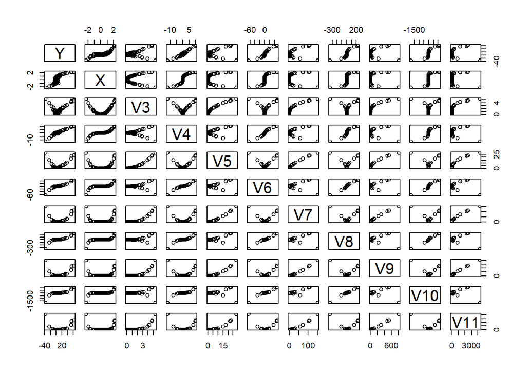

```r
plot(mdata_df)
```

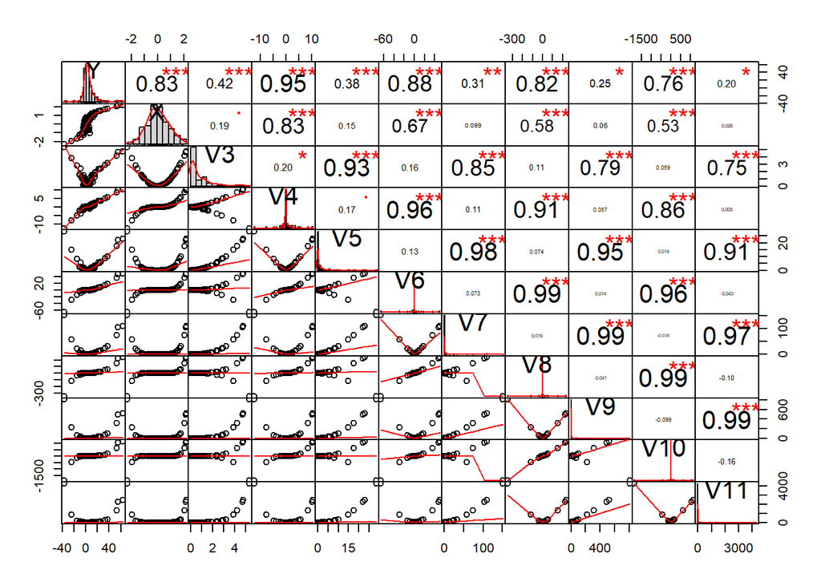

```r
chart.Correlation(mdata_df,histogram = T,pch=19)
```